# Infopoints im Überblick Datenstand: 2026-09-28

**Executive Summary**

Datengrundlage / Anzahl an Infopoints

5233 ↑ 1.6%

Analyse-Basis: aktiv & nicht storniert (72.5% der aktiven inkl. storniert)

8544

Infopoints gesamt (alle Projekte inkl. on hold)

7216

In aktiven Projekten — ohne on hold (97 Projekten)

1983

Davon storniert (27.5% der aktiven inkl. storniert)

Infopunkte je Status

2058 ↑ 0.7%

39.3%

receive

1131 ↓ 13.9%

21.6%

open

660 ↓ 1.2%

12.6%

applied for — davon 400 (60.6%) > 12 Wochen offen

506 ↑ 1.4%

9.7%

rejected

336 ↑ 0.6%

6.4%

no response

523 ↑ 95.1%

10%

borderline case

19 ↓ 13.6%

0.4%

NA / leer

Leitungsrechte

1052 ↑ 0.2%

Gebaut, aber Status ≠ receive (20.1% ohne storniert)

375 ↑ 14%

Feeder ohne LR (gesamt)

29

Feeder ohne LR — Planung

177

Feeder ohne LR — im Bau

169

Feeder ohne LR — Bau fertig

227 ↑ 5.6%

Feeder gebaut ohne LR (gesamt)

2

Feeder gebaut ohne LR — Planung

60

Feeder gebaut ohne LR — im Bau

165

Feeder gebaut ohne LR — Bau fertig

Abgeltungen

749

Payment required = Yes (14.3% ohne storniert)

184

Qualifiziert: Built & receive (24.6% der Abgeltungen)

**Note**

Alle Zahlen und Prozentangaben beziehen sich auf **5233 aktive, nicht stornierte Infopoints** in 97 Projekten (ohne on hold). Ausgefiltert: 1983 storniert + 1328 in on hold Projekten. Die Prozentangaben zeigen die Veränderung zur Vorwoche.

**Kapitel 1: Status-Übersicht nach Projekt**

Übersicht aller Infopoints nach Bau/Planung-Status, PB, LR-Akquise und Projekt — aufgeschlüsselt nach den möglichen Status-Werten. Stornierte Infopoints sind hier zur Vollständigkeit mitgezeigt; in allen anderen Kapiteln sind sie ausgeschlossen.

### 1.1 Status-Übersicht nach Projekt

| Bau/Planung | PB | LR-Akquise | Projekt | Leer | open | applied for | receive | rejected | no response | canceled | Gesamt |
| --- | --- | --- | --- | --- | --- | --- | --- | --- | --- | --- | --- |
| Bau fertig | DPB | DPB | 2041901, Maria Wörth | 0 | 44 | 3 | 16 | 12 | 3 | 30 | 108 |
| Bau fertig | Kornfeld | Energiekanzlei | 30401001, Wiener Neustadt 1 | 0 | 4 | 0 | 3 | 3 | 0 | 13 | 35 |
| Bau fertig | Kornfeld | Energiekanzlei | 30401006, Wiener Neustadt 6 | 0 | 0 | 7 | 1 | 2 | 2 | 6 | 22 |
| Bau fertig | Telecs | Telecs | 30612, Günselsdorf | 0 | 8 | 3 | 4 | 2 | 0 | 9 | 26 |
| Bau fertig | ZEIB | ZEIB | 3061601, Klausen-Leopoldsdorf | 0 | 7 | 1 | 2 | 0 | 0 | 0 | 10 |
| Bau fertig | ZEIB | ZEIB | 3061801, Kottingbrunn | 0 | 62 | 2 | 45 | 11 | 4 | 27 | 151 |
| Bau fertig | SPIE KEM | Energiekanzlei | 30639, Traiskirchen-Oeynhausen | 0 | 0 | 0 | 9 | 2 | 1 | 4 | 23 |
| Bau fertig | SPIE KEM | Energiekanzlei | 30639, Traiskirchen-Tribuswinkel | 0 | 0 | 0 | 3 | 2 | 0 | 40 | 45 |
| Bau fertig | ZEIB | ZEIB | 30706, Enzersdorf an der Fischa | 0 | 16 | 0 | 6 | 1 | 0 | 20 | 43 |
| Bau fertig | ZEIB | ZEIB | 3071601, Mannersdorf am Leithagebirge | 0 | 64 | 12 | 23 | 0 | 0 | 2 | 102 |

[output cut: 86 more lines]

⬇ Tabelle (CSV) ⬇ Rohdaten (CSV)

### 1.2 Status und Building Type

**Infopoints nach Status und Building Type**

| Status | Total | Total % | estate | estate % | private road | private road % | NA | NA % | WEG | WEG % | serial house | serial house % |
| --- | --- | --- | --- | --- | --- | --- | --- | --- | --- | --- | --- | --- |
| NA / leer | 19 | 100 | 8 | 42.1 | 1 | 5.3 | 10 | 52.6 | 0 | 0 | 0 | 0 |
| applied for | 660 | 100 | 265 | 40.2 | 324 | 49.1 | 13 | 2 | 9 | 1.4 | 49 | 7.4 |
| borderline case | 523 | 100 | 249 | 47.6 | 6 | 1.1 | 268 | 51.2 | 0 | 0 | 0 | 0 |
| no response | 336 | 100 | 221 | 65.8 | 100 | 29.8 | 4 | 1.2 | 3 | 0.9 | 8 | 2.4 |
| open | 1131 | 100 | 771 | 68.2 | 238 | 21 | 42 | 3.7 | 5 | 0.4 | 75 | 6.6 |
| receive | 2058 | 100 | 1281 | 62.2 | 647 | 31.4 | 18 | 0.9 | 44 | 2.1 | 68 | 3.3 |
| rejected | 506 | 100 | 267 | 52.8 | 205 | 40.5 | 5 | 1 | 10 | 2 | 19 | 3.8 |

⬇ Tabelle (CSV) ⬇ Rohdaten (CSV)

**Warning⚠️ Infopoints ohne Status**

**19 Infopoints** in dieser Tabelle haben keinen Status-Eintrag (`NA / leer`). Diese sollten bereinigt werden.

### 1.3 Status und FeederDropBackbone

**Infopoints nach Status und FeederDropBackbone**

| Status | Total | Total % | Drop Level | Drop Level % | NA | NA % | Feeder Level | Feeder Level % | Backbone Level | Backbone Level % |
| --- | --- | --- | --- | --- | --- | --- | --- | --- | --- | --- |
| NA / leer | 19 | 100 | 9 | 47.4 | 10 | 52.6 | 0 | 0 | 0 | 0 |
| applied for | 660 | 100 | 538 | 81.5 | 7 | 1.1 | 115 | 17.4 | 0 | 0 |
| borderline case | 523 | 100 | 205 | 39.2 | 200 | 38.2 | 118 | 22.6 | 0 | 0 |
| no response | 336 | 100 | 293 | 87.2 | 0 | 0 | 43 | 12.8 | 0 | 0 |
| open | 1131 | 100 | 1023 | 90.5 | 30 | 2.7 | 77 | 6.8 | 1 | 0.1 |
| receive | 2058 | 100 | 1505 | 73.1 | 13 | 0.6 | 540 | 26.2 | 0 | 0 |
| rejected | 506 | 100 | 482 | 95.3 | 2 | 0.4 | 22 | 4.3 | 0 | 0 |

⬇ Tabelle (CSV) ⬇ Rohdaten (CSV)

**Warning⚠️ Infopoints ohne Status**

**19 Infopoints** in dieser Tabelle haben keinen Status-Eintrag (`NA / leer`). Diese sollten bereinigt werden.

#### 1.3.1 Fehlende FeederDrop-Informationen nach Projekt

Projekte, bei denen Infopoints keinen FeederDropBackbone eingetragen haben (weder Drop Level noch Feeder Level).

**Zusammenfassung nach Planungsbüro (PB):**

**Fehlende FeederDrop-Informationen nach PB**

| PB | Total | Total % | Drop Level | Drop Level % | Feeder Level | Feeder Level % | NA | NA % |
| --- | --- | --- | --- | --- | --- | --- | --- | --- |
| Kastner | 268 | 100 | 145 | 54.1 | 33 | 12.3 | 90 | 33.6 |
| CCE | 289 | 100 | 195 | 67.5 | 46 | 15.9 | 48 | 16.6 |
| IKW | 257 | 100 | 179 | 69.6 | 38 | 14.8 | 39 | 15.2 |
| Terra consul | 369 | 100 | 267 | 72.4 | 67 | 18.2 | 35 | 9.5 |
| GisQuadrat | 168 | 100 | 152 | 90.5 | 1 | 0.6 | 15 | 8.9 |
| moleplan | 154 | 100 | 117 | 76 | 29 | 18.8 | 8 | 5.2 |
| Umwelt & Bau | 403 | 100 | 348 | 86.4 | 48 | 11.9 | 7 | 1.7 |
| KPP | 874 | 100 | 683 | 78.1 | 186 | 21.3 | 5 | 0.6 |
| Telecs | 61 | 100 | 53 | 86.9 | 3 | 4.9 | 5 | 8.2 |
| GWK | 1010 | 100 | 804 | 79.6 | 202 | 20 | 4 | 0.4 |

[output cut: 2 more lines]

⬇ Tabelle (CSV) ⬇ Rohdaten (CSV)

**Aufschlüsselung nach Projekt:**

**Fehlende FeederDrop-Informationen nach Projekt**

| Planned by | PB | Total | Total % | Drop Level | Drop Level % | Feeder Level | Feeder Level % | NA | NA % |
| --- | --- | --- | --- | --- | --- | --- | --- | --- | --- |
| 20635, Spittal an der Drau | Kastner | 185 | 100 | 90 | 48.6 | 13 | 7 | 82 | 44.3 |
| 4070401, Ebensee am Traunsee | Terra consul | 221 | 100 | 156 | 70.6 | 30 | 13.6 | 35 | 15.8 |
| 20201003, Villach - Untere Fellach | CCE | 86 | 100 | 45 | 52.3 | 12 | 14 | 29 | 33.7 |
| 30608, Enzesfeld-Lindabrunn | IKW | 51 | 100 | 33 | 64.7 | 1 | 2 | 17 | 33.3 |
| 20630, Radenthein | GisQuadrat | 105 | 100 | 90 | 85.7 | 0 | 0 | 15 | 14.3 |
| 20201002, Villach - Innere Stadt | CCE | 48 | 100 | 27 | 56.2 | 11 | 22.9 | 10 | 20.8 |
| 4140201, Andorf | IKW | 77 | 100 | 52 | 67.5 | 14 | 18.2 | 10 | 13 |
| 20201005, Villach - Auen | CCE | 43 | 100 | 23 | 53.5 | 12 | 27.9 | 8 | 18.6 |
| 62379, Feldbach | moleplan | 154 | 100 | 117 | 76 | 29 | 18.8 | 8 | 5.2 |
| 30615, Hirtenberg | IKW | 14 | 100 | 6 | 42.9 | 1 | 7.1 | 7 | 50 |

[output cut: 18 more lines]

⬇ Tabelle (CSV) ⬇ Rohdaten (CSV)

**Kapitel 2: Abgeltungen, Built und HP dahinter**

Handlungsbedarf (receive + gebaut)

154

A — Zahlen & payed setzen (18.3% von receive+gebaut)

30

B — Klären: Costs leer (3.6% von receive+gebaut)

### 2.1 Abgeltungen — Datencheck

#### 2.1.1 Payment required = Yes, aber Costs leer

Infopoints, bei denen eine Zahlung erforderlich ist, aber kein Kostenbetrag eingetragen wurde.

**Anzahl betroffener Infopoints:** 157 (3%)

⬇ Tabelle (CSV) ⬇ Rohdaten (CSV)

#### 2.1.2 Costs > 0, aber Payment required = No

**Anzahl betroffener Infopoints:** 11 (0.2%)

⬇ Tabelle (CSV) ⬇ Rohdaten (CSV)

**Warning**

**Hinweis Kostenformat:** Es wurden 70 (1.3%) Zeilen mit nicht-standardisierten Kostenformaten gefunden (z.B. `482,80 € (2x 241,40€)`). Diese sollten manuell geprüft werden, falls gewünscht.

#### 2.1.3 Abgeltungen: Qualifikationsstatus nach Projekt

Infopoints mit **Payment required = Yes** — Fortschrittstrichter pro Projekt. Eine Abgeltung gilt als **vollständig qualifiziert**, wenn beide Bedingungen erfüllt sind: `Built = Yes` **und** `Status = receive`. Nicht qualifizierte Infopoints werden nach Ablehnungsgrund aufgeschlüsselt.

**Abgeltungen nach Projekt: Qualifikationsstatus**

| Planned by | PB | Payment = Yes | Qualifiziert (Built & receive) | Qualifiziert % | Nicht gebaut & kein receive | Nicht gebaut & kein receive % | Gebaut, kein receive | Gebaut, kein receive % | Receive, nicht gebaut | Receive, nicht gebaut % |
| --- | --- | --- | --- | --- | --- | --- | --- | --- | --- | --- |
| 20630, Radenthein | GisQuadrat | 67 | 0 | 0 | 67 | 100 | 0 | 0 | 0 | 0 |
| 60624, Kalsdorf bei Graz | GWK | 66 | 0 | 0 | 0 | 0 | 0 | 0 | 0 | 0 |
| 20527, St. Veit an der Glan | GisQuadrat | 40 | 0 | 0 | 30 | 75 | 0 | 0 | 10 | 25 |
| 20923, Wolfsberg | DPB | 36 | 17 | 47.2 | 0 | 0 | 6 | 16.7 | 12 | 33.3 |
| 21002, Feldkirchen in Kärnten | Kastner | 33 | 0 | 0 | 19 | 57.6 | 0 | 0 | 14 | 42.4 |
| 2041901, Maria Wörth | DPB | 29 | 2 | 6.9 | 10 | 34.5 | 14 | 48.3 | 3 | 10.3 |
| 3183901, Ternitz | KPP | 27 | 13 | 48.1 | 0 | 0 | 10 | 37 | 1 | 3.7 |
| 6066901, Seiersberg-Pirka 1 (West) | Umwelt & Bau | 27 | 4 | 14.8 | 1 | 3.7 | 1 | 3.7 | 2 | 7.4 |
| 40201001, Steyr_1 | KPP | 26 | 4 | 15.4 | 11 | 42.3 | 1 | 3.8 | 10 | 38.5 |
| 60669002, Seiersberg-Pirka 2 (Ost) | GWK | 26 | 0 | 0 | 0 | 0 | 0 | 0 | 0 | 0 |

[output cut: 57 more lines]

⬇ Tabelle (CSV) ⬇ Rohdaten (CSV)

#### 2.1.4 Abgeltungen: Handlungsbedarf — receive + gebaut

Infopoints mit `Status = receive` **und** `Built = Yes` — LR bereits erhalten, Infopoint gebaut.

**Note**

**Gruppe A — Zahlen & “payed” setzen:** `Payment required = Yes` und `Costs > 0` → Rechnung liegt vor, Abgeltung ist fällig.

**Gruppe B — Klären:** `Payment required = Yes` und `Costs leer` → Unklar ob wirklich keine Kosten anfallen oder ob das Feld vergessen wurde.

**Basis: 840 Infopoints** mit Status = receive und Built = Yes.

**Handlungsbedarf nach Projekt (receive + gebaut)**

| Planned by | PB | Receive & Built | A: Zahlen | A: Zahlen % | B: Klären | B: Klären % |
| --- | --- | --- | --- | --- | --- | --- |
| 6066901, Seiersberg-Pirka 1 (West) | Umwelt & Bau | 86 | 4 | 4.7 | 0 | 0 |
| 4070401, Ebensee am Traunsee | Terra consul | 78 | 5 | 6.4 | 0 | 0 |
| 4170101, Ampflwang | Terra consul | 50 | 10 | 20 | 7 | 14 |
| 6221901, Hartberg | Umwelt & Bau | 50 | 5 | 10 | 8 | 16 |
| 3061801, Kottingbrunn | ZEIB | 45 | 0 | 0 | 0 | 0 |
| 4173801, Schwanenstadt | KPP | 45 | 4 | 8.9 | 3 | 6.7 |
| 60101004, Graz_04_Mariatroster_Straße | GWK | 38 | 8 | 21.1 | 1 | 2.6 |
| 3183901, Ternitz | KPP | 37 | 13 | 35.1 | 0 | 0 |
| 4071101, Laakirchen | Terra consul | 35 | 11 | 31.4 | 0 | 0 |
| 70309, Fritzens | Hauser | 35 | 6 | 17.1 | 2 | 5.7 |

[output cut: 44 more lines]

⬇ Tabelle (CSV) ⬇ Rohdaten (CSV)

### 2.2 Built Yes/No — Datencheck

#### 2.2.1 Status von “built” pro Projekt

**Zusammenfassung über alle 94 Projekte:**

| Kennzahl | Anzahl Projekte |
| --- | --- |
| 0 “Yes” (kein einziger gebaut) | 27 |
| 0 “No” (alle gebaut oder offen) | 16 |
| 100% “Yes” (alle gebaut) | 0 |
| 100% “No” (keiner gebaut) | 5 |

**Built-Status je Projekt**

| Planned by | PB | Total | Total % | Built: Yes | Built: Yes % | Built: No | Built: No % | Built: leer | Built: leer % |
| --- | --- | --- | --- | --- | --- | --- | --- | --- | --- |
| 20201001, Villach - Warmbad | CCE | 78 | 100 | 0 | 0 | 0 | 0 | 78 | 100 |
| 20201002, Villach - Innere Stadt | CCE | 48 | 100 | 0 | 0 | 0 | 0 | 48 | 100 |
| 20201003, Villach - Untere Fellach | CCE | 86 | 100 | 0 | 0 | 1 | 1.2 | 85 | 98.8 |
| 20201004, Villach - Bahnhofsviertel - Seebach | Fionis | 37 | 100 | 7 | 18.9 | 13 | 35.1 | 17 | 45.9 |
| 20201005, Villach - Auen | CCE | 43 | 100 | 0 | 0 | 0 | 0 | 43 | 100 |
| 2041901, Maria Wörth | DPB | 78 | 100 | 46 | 59 | 32 | 41 | 0 | 0 |
| 20515, Liebenfels | Kastner | 9 | 100 | 0 | 0 | 0 | 0 | 9 | 100 |
| 20527, St. Veit an der Glan | GisQuadrat | 52 | 100 | 0 | 0 | 52 | 100 | 0 | 0 |
| 20630, Radenthein | GisQuadrat | 105 | 100 | 0 | 0 | 78 | 74.3 | 27 | 25.7 |
| 2063401, Seeboden am Millstätter See | CCE | 34 | 100 | 0 | 0 | 11 | 32.4 | 23 | 67.6 |

[output cut: 84 more lines]

⬇ Tabelle (CSV) ⬇ Rohdaten (CSV)

**Projekte mit 100% “Built: No”:**

**Projekte mit 100% Built: No**

| Planned by | PB | Total | Total % | Built: No | Built: No % |
| --- | --- | --- | --- | --- | --- |
| 20527, St. Veit an der Glan | GisQuadrat | 52 | 100 | 52 | 100 |
| 30502002, Amstetten Mitte_2 | IKW | 12 | 100 | 12 | 100 |
| 30502003, Amstetten Süd_3 | IKW | 11 | 100 | 11 | 100 |
| 30605, St. Veit an der Triesting | GisQuadrat | 11 | 100 | 11 | 100 |
| 30639, Traiskirchen-Tribuswinkel | SPIE KEM | 5 | 100 | 5 | 100 |

⬇ Tabelle (CSV) ⬇ Rohdaten (CSV)

#### 2.2.2 Built: Yes/No nach Status

**Built-Status nach Status**

| Status | Total | Total % | Built: Yes | Built: Yes % | Built: No | Built: No % | Built: leer | Built: leer % |
| --- | --- | --- | --- | --- | --- | --- | --- | --- |
| NA / leer | 19 | 100 | 0 | 0 | 2 | 10.5 | 17 | 89.5 |
| applied for | 660 | 100 | 120 | 18.2 | 252 | 38.2 | 288 | 43.6 |
| borderline case | 523 | 100 | 266 | 50.9 | 8 | 1.5 | 249 | 47.6 |
| no response | 336 | 100 | 120 | 35.7 | 100 | 29.8 | 116 | 34.5 |
| open | 1131 | 100 | 522 | 46.2 | 355 | 31.4 | 254 | 22.5 |
| receive | 2058 | 100 | 840 | 40.8 | 646 | 31.4 | 572 | 27.8 |
| rejected | 506 | 100 | 24 | 4.7 | 263 | 52 | 219 | 43.3 |

**Important🔴 Infopoints ohne Status-Eintrag**

**19 Infopoints** haben keinen Status-Eintrag (`NA / leer`). Diese Zeile ist in der Tabelle oben rot hervorgehoben. Bitte bereinigen — ein fehlender Status verhindert korrekte Auswertungen in allen Kapiteln.

⬇ Tabelle (CSV) ⬇ Rohdaten (CSV)

**Warning⚠️ Gebaut, aber Status nicht ‘receive’**

**1052 Infopoints** (`20.1%` aller) haben `Built = Yes`, aber der Status ist noch nicht auf **receive** gesetzt. Diese Zeilen sind in der Tabelle oben amber hervorgehoben.

**Kapitel 3: Zeitkomponente — “Applied for” & “Open”**

Dieses Kapitel analysiert, wie lange Infopoints in den Status **“applied for”** und **“open”** verbleiben — für “applied for” gemessen ab dem Datum in “Requested on”, für “open” ab dem Datum in “Creation time”, jeweils bis heute (2026-09-28).

### 3.1 Übersicht: “Applied for”

**Gesamtanzahl Infopoints mit Status “applied for”:** 660 (12.6%)

**Davon ohne Datum in “Requested on”:** 203 (30.8%)

**Davon mit Datum in “Requested on”:** 457 (69.2%)

**Warning⚠️ Fehlende Datumsangaben**

**203 Infopoints** haben den Status “applied for”, aber kein Datum in “Requested on”. Diese können nicht in die Zeitanalyse einbezogen werden und sollten manuell geprüft werden.

**Projekte mit mindestens einem “applied for” Infopoint:** 67 von 94 Projekten (71.3%)

**Offene 'Applied for' Infopoints nach Wartezeit**

| Schwellenwert | Anzahl Infopoints | Anzahl Infopoints % |
| --- | --- | --- |
| < 4 Wochen | 27 | 5.9 |
| 4–8 Wochen | 13 | 2.8 |
| 8–12 Wochen | 17 | 3.7 |
| > 12 Wochen | 400 | 87.5 |

⬇ Tabelle (CSV) ⬇ Rohdaten (CSV)

### 3.2 Aufschlüsselung nach Projekt

**Applied for Infopoints nach Projekt und Wartezeit**

| Bau_Planung | Planned by | PB | Total applied for | Total applied for % | Kein Datum | Kein Datum % | < 4 Wochen | < 4 Wochen % | 4–8 Wochen | 4–8 Wochen % | 8–12 Wochen | 8–12 Wochen % | > 12 Wochen | > 12 Wochen % |
| --- | --- | --- | --- | --- | --- | --- | --- | --- | --- | --- | --- | --- | --- | --- |
| Bau fertig | 30735, Leopoldsdorf | Gisquadrat | 19 | 100 | 0 | 0 | 0 | 0 | 0 | 0 | 0 | 0 | 19 | 100 |
| Bau fertig | 40201001, Steyr_1 | KPP | 17 | 100 | 1 | 5.9 | 1 | 5.9 | 0 | 0 | 3 | 17.6 | 12 | 70.6 |
| Bau fertig | 3071601, Mannersdorf am Leithagebirge | ZEIB | 12 | 100 | 12 | 100 | 0 | 0 | 0 | 0 | 0 | 0 | 0 | 0 |
| Bau fertig | 3180401, Breitenau am Steinfelde | IKW | 8 | 100 | 8 | 100 | 0 | 0 | 0 | 0 | 0 | 0 | 0 | 0 |
| Bau fertig | 30401006, Wiener Neustadt 6 | Kornfeld | 7 | 100 | 0 | 0 | 0 | 0 | 0 | 0 | 0 | 0 | 7 | 100 |
| Bau fertig | 3191801, Kirchberg an der Pielach | ZEIB | 5 | 100 | 5 | 100 | 0 | 0 | 0 | 0 | 0 | 0 | 0 | 0 |
| Bau fertig | 4080201, Wallern | GWK | 5 | 100 | 0 | 0 | 0 | 0 | 0 | 0 | 0 | 0 | 5 | 100 |
| Bau fertig | 2041901, Maria Wörth | DPB | 3 | 100 | 0 | 0 | 0 | 0 | 0 | 0 | 0 | 0 | 3 | 100 |
| Bau fertig | 30612, Günselsdorf | Telecs | 3 | 100 | 3 | 100 | 0 | 0 | 0 | 0 | 0 | 0 | 0 | 0 |
| Bau fertig | 40809, Haag am Hausruck | GWK | 3 | 100 | 1 | 33.3 | 0 | 0 | 0 | 0 | 0 | 0 | 2 | 66.7 |

[output cut: 57 more lines]

⬇ Tabelle (CSV) ⬇ Rohdaten (CSV)

### 3.3 Histogramm: Wartezeit seit “applied for”

Verteilung der Wochen seit Statussetzen auf “applied for” für alle Infopoints mit gültigem Datum (n = 457). Maximaler Wert: **117 Wochen** (819 Tage).

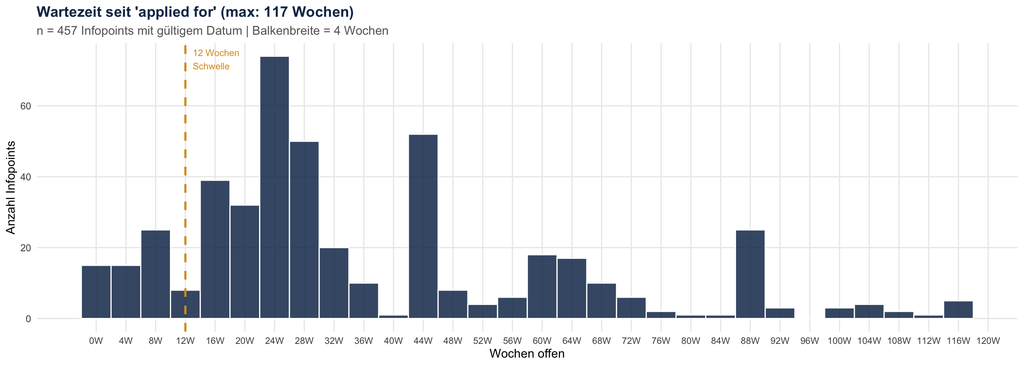

### 3.4 Übersicht: “Open”

**Gesamtanzahl Infopoints mit Status “open”:** 1131 (21.6%)

**Davon ohne Datum in “Creation time”:** 0 (0%)

**Davon mit Datum in “Creation time”:** 1131 (100%)

**Offene 'Open' Infopoints nach Wartezeit**

| Schwellenwert | Anzahl Infopoints | Anzahl Infopoints % |
| --- | --- | --- |
| < 4 Wochen | 31 | 2.7 |
| 4–8 Wochen | 25 | 2.2 |
| 8–12 Wochen | 10 | 0.9 |
| > 12 Wochen | 1065 | 94.2 |

### 3.5 Aufschlüsselung nach Projekt

**Open Infopoints nach Projekt und Wartezeit**

| Bau_Planung | Planned by | PB | Total open | Total open % | Kein Datum | Kein Datum % | < 4 Wochen | < 4 Wochen % | 4–8 Wochen | 4–8 Wochen % | 8–12 Wochen | 8–12 Wochen % | > 12 Wochen | > 12 Wochen % |
| --- | --- | --- | --- | --- | --- | --- | --- | --- | --- | --- | --- | --- | --- | --- |
| Bau fertig | 3071601, Mannersdorf am Leithagebirge | ZEIB | 64 | 100 | 0 | 0 | 0 | 0 | 0 | 0 | 0 | 0 | 64 | 100 |
| Bau fertig | 3061801, Kottingbrunn | ZEIB | 62 | 100 | 0 | 0 | 0 | 0 | 0 | 0 | 0 | 0 | 62 | 100 |
| Bau fertig | 40201001, Steyr_1 | KPP | 60 | 100 | 0 | 0 | 0 | 0 | 0 | 0 | 0 | 0 | 60 | 100 |
| Bau fertig | 3101501, Hadres | IKW | 48 | 100 | 0 | 0 | 2 | 4.2 | 0 | 0 | 0 | 0 | 46 | 95.8 |
| Bau fertig | 2041901, Maria Wörth | DPB | 44 | 100 | 0 | 0 | 0 | 0 | 0 | 0 | 0 | 0 | 44 | 100 |
| Bau fertig | 3191801, Kirchberg an der Pielach | ZEIB | 42 | 100 | 0 | 0 | 0 | 0 | 0 | 0 | 0 | 0 | 42 | 100 |
| Bau fertig | 4130901, Haslach an der Mühl | GWK | 34 | 100 | 0 | 0 | 0 | 0 | 0 | 0 | 0 | 0 | 34 | 100 |
| Bau fertig | 3193501, Rabenstein an der Pielach | KPP | 31 | 100 | 0 | 0 | 0 | 0 | 0 | 0 | 0 | 0 | 31 | 100 |
| Bau fertig | 40818, Neumarkt im Hausruckkreis | GWK | 24 | 100 | 0 | 0 | 0 | 0 | 0 | 0 | 0 | 0 | 24 | 100 |
| Bau fertig | 4182001, Stadl-Paura | KPP | 21 | 100 | 0 | 0 | 0 | 0 | 0 | 0 | 0 | 0 | 21 | 100 |

[output cut: 57 more lines]

⬇ Tabelle (CSV) ⬇ Rohdaten (CSV)

### 3.6 Histogramm: Wartezeit seit “open”

Maximaler Wert: **123 Wochen** (861 Tage).

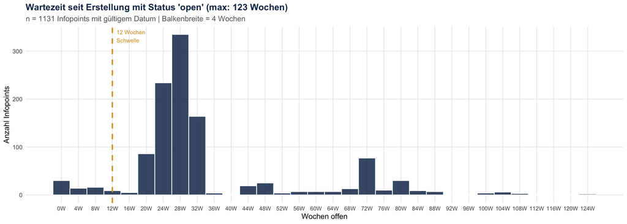

⬇ Tabelle (CSV) ⬇ Rohdaten (CSV)

**Kapitel 4: Bau/Planung-Kontext**

Dieses Kapitel analysiert Datenqualitätsprobleme **im Kontext des Bau/Planung-Status** der jeweiligen Projekte. Issues in Projekten mit Status **“Bau fertig”** sind dringlicher als solche in Projekten, die noch in Planung sind.

### 4.1 Überblick: Infopoints nach Bau/Planung-Status

**Infopoints nach Bau/Planung-Status**

| Bau_Planung | Total | Total % | Ohne Status | Ohne Status % | Built = Yes | Built = Yes % | Built = No | Built = No % | Payment = Yes | Payment = Yes % | Applied for | Applied for % | No response | No response % |
| --- | --- | --- | --- | --- | --- | --- | --- | --- | --- | --- | --- | --- | --- | --- |
| Bau fertig | 1546 | 100 | 6 | 0.4 | 1079 | 69.8 | 430 | 27.8 | 162 | 10.5 | 93 | 6 | 99 | 6.4 |
| Planung | 527 | 100 | 2 | 0.4 | 3 | 0.6 | 291 | 55.2 | 218 | 41.4 | 142 | 26.9 | 36 | 6.8 |
| im Bau | 3160 | 100 | 11 | 0.3 | 810 | 25.6 | 905 | 28.6 | 369 | 11.7 | 425 | 13.4 | 201 | 6.4 |

⬇ Tabelle (CSV) ⬇ Rohdaten (CSV)

### 4.2 Kritische Issues nach Bau/Planung-Status

#### 4.2.1 Gebaut, aber Status ≠ receive — nach Bau/Planung

**Gebaut & Status ≠ receive: nach Bau/Planung-Status**

| Bau_Planung | Anzahl | Projekte | % von Gesamt |
| --- | --- | --- | --- |
| Bau fertig | 715 | 29 | 13.7 |
| im Bau | 334 | 31 | 6.4 |
| Planung | 3 | 1 | 0.1 |

⬇ Tabelle (CSV) ⬇ Rohdaten (CSV)

#### 4.2.2 Ohne Status-Eintrag — nach Bau/Planung

**Ohne Status-Eintrag: nach Bau/Planung-Status**

| Bau_Planung | Anzahl | Projekte | % von Gesamt |
| --- | --- | --- | --- |
| im Bau | 11 | 2 | 0.2 |
| Bau fertig | 6 | 4 | 0.1 |
| Planung | 2 | 2 | 0 |

⬇ Tabelle (CSV) ⬇ Rohdaten (CSV)

#### 4.2.3 Payment = Yes, Abgeltung nicht qualifiziert — nach Bau/Planung

**Offene Abgeltungen (nicht qualifiziert): nach Bau/Planung-Status**

| Bau_Planung | Anzahl offen | davon gebaut, kein receive | davon nicht gebaut | Projekte | % von Payment=Yes |
| --- | --- | --- | --- | --- | --- |
| Planung | 213 | 0 | 185 | 13 | 28.4 |
| im Bau | 194 | 20 | 90 | 30 | 25.9 |
| Bau fertig | 81 | 25 | 56 | 11 | 10.8 |

⬇ Tabelle (CSV) ⬇ Rohdaten (CSV)

**Kapitel 5: Gebaut ohne Leitungsrecht**

Infopoints mit `Built = Yes` **und** `Status ≠ receive` (fehlender Status zählt hier als “≠ receive”) — die physische Infrastruktur ist vorhanden, das Leitungsrecht aber noch nicht gesichert. Basis: alle aktiven, nicht-stornierten Infopoints (5233), gefiltert auf `Built = Yes`; davon ausgeschlossen sind nur Infopoints mit `Status = receive`.

**Warning⚠️ Gebaut ohne gesichertes Leitungsrecht**

**1052 Infopoints** (20.1% aller aktiven) sind gebaut, haben aber noch keinen `receive`-Status.

### 5.1 Nach Status

**Gebaut ohne LR — nach Status**

| Status | Total | % von Gesamt |
| --- | --- | --- |
| open | 522 | 49.6 |
| borderline case | 266 | 25.3 |
| applied for | 120 | 11.4 |
| no response | 120 | 11.4 |
| rejected | 24 | 2.3 |

⬇ Tabelle (CSV) ⬇ Rohdaten (CSV)

### 5.2 Nach FeederDropBackbone

**Gebaut ohne LR — nach FeederDropBackbone**

| FeederDropBackbone | Total | % von Gesamt |
| --- | --- | --- |
| Drop Level | 823 | 78.2 |
| Feeder Level | 227 | 21.6 |
| NA / leer | 2 | 0.2 |

⬇ Tabelle (CSV) ⬇ Rohdaten (CSV)

### 5.3 Nach Bau/Planung-Phase

**Gebaut ohne LR — nach Bau/Planung-Phase**

| Bau_Planung | Total | Projekte | % von Gesamt |
| --- | --- | --- | --- |
| Bau fertig | 715 | 29 | 68 |
| im Bau | 334 | 31 | 31.7 |
| Planung | 3 | 1 | 0.3 |

⬇ Tabelle (CSV) ⬇ Rohdaten (CSV)

### 5.4 Kreuztabelle: Status × FeederDropBackbone

**Gebaut ohne LR — Status × FeederDropBackbone**

| Status | Total | Total % | Drop Level | Drop Level % | Feeder Level | Feeder Level % | NA / leer | NA / leer % |
| --- | --- | --- | --- | --- | --- | --- | --- | --- |
| open | 522 | 100 | 454 | 87 | 67 | 12.8 | 1 | 0.2 |
| borderline case | 266 | 100 | 184 | 69.2 | 82 | 30.8 | 0 | 0 |
| applied for | 120 | 100 | 83 | 69.2 | 36 | 30 | 1 | 0.8 |
| no response | 120 | 100 | 82 | 68.3 | 38 | 31.7 | 0 | 0 |
| rejected | 24 | 100 | 20 | 83.3 | 4 | 16.7 | 0 | 0 |

⬇ Tabelle (CSV) ⬇ Rohdaten (CSV)

### 5.5 Aufschlüsselung nach Projekt

**Gebaut ohne LR — nach Projekt und FeederDropBackbone**

| Planned by | PB | Bau_Planung | Drop Level | Feeder Level | NA / leer | Total | % von Gesamt |
| --- | --- | --- | --- | --- | --- | --- | --- |
| 40818, Neumarkt im Hausruckkreis | GWK | Bau fertig | 50 | 36 | 0 | 86 | 8.2 |
| 4130901, Haslach an der Mühl | GWK | Bau fertig | 63 | 18 | 0 | 81 | 7.7 |
| 4173801, Schwanenstadt | KPP | Bau fertig | 49 | 27 | 0 | 76 | 7.2 |
| 3071601, Mannersdorf am Leithagebirge | ZEIB | Bau fertig | 56 | 11 | 0 | 67 | 6.4 |
| 3060701, Ebreichsdorf | ZEIB | im Bau | 55 | 5 | 0 | 60 | 5.7 |
| 6066901, Seiersberg-Pirka 1 (West) | Umwelt & Bau | im Bau | 53 | 3 | 0 | 56 | 5.3 |
| 3191801, Kirchberg an der Pielach | ZEIB | Bau fertig | 39 | 6 | 0 | 45 | 4.3 |
| 4140201, Andorf | IKW | Bau fertig | 37 | 8 | 0 | 45 | 4.3 |
| 3061801, Kottingbrunn | ZEIB | Bau fertig | 32 | 9 | 0 | 41 | 3.9 |
| 2041901, Maria Wörth | DPB | Bau fertig | 31 | 9 | 0 | 40 | 3.8 |

[output cut: 51 more lines]

⬇ Tabelle (CSV) ⬇ Rohdaten (CSV)

**Kapitel 6: LR im Zeitverlauf**

Entwicklung der Infopoints je Status über die Zeit (wöchentlich), basierend auf der Zusammenfassung in `LR-Statusentwicklung_piha_neu.xlsx` (Tabellenblatt `Statusentwicklung`). On-hold Projekte wurden nicht einbezogen.

### 6.1 Entwicklung nach Status

[interactive chart not shown]

### 6.2 Rohdaten

**LR-Statusentwicklung je Kalenderwoche**

| kw | Abgelehnt | Angesucht | Erhalten | Offen | Storniert | No_Response | Borderline_Case |
| --- | --- | --- | --- | --- | --- | --- | --- |
| KW 06 | 359 | 950 | 1224 | 659 | 698 | 0 | NA |
| KW 07 | 360 | 948 | 1259 | 638 | 728 | 0 | NA |
| KW 08 | 375 | 945 | 1264 | 773 | 724 | 0 | NA |
| KW 09 | 321 | 918 | 1288 | 1015 | 817 | 0 | NA |
| KW 11 | 330 | 900 | 1322 | 1424 | 823 | 0 | NA |
| KW 12 | 338 | 909 | 1351 | 1452 | 828 | 0 | NA |
| KW 13 | 346 | 936 | 1362 | 1580 | 848 | 0 | NA |
| KW 14 | 360 | 920 | 1383 | 1907 | 943 | 0 | NA |
| KW 15 | 361 | 892 | 1424 | 1839 | 1130 | 0 | NA |
| KW 16 | 398 | 1016 | 1444 | 1956 | 1211 | 0 | NA |

[output cut: 20 more lines]

⬇ Tabelle (CSV) ⬇ Rohdaten (CSV)

**Kapitel 7: Projektseiten**

Projekt auswählen, um die wichtigsten Kennzahlen ausschließlich für dieses Projekt zu sehen: Status-Verteilung, FeederDropBackbone, Built-Status und die Zeitkomponente (applied for / open).

Projekt suchen

Klicken zum Auswählen

Baulos

⚠️ Achtung, nicht alle Baulose sind relevant!

Feeder/Drop/Backbone

Drop Level Feeder Level Backbone NA / leer

PCM Planungsbüro (PB) Projektstatus

Bitte mindestens ein Projekt oben auswählen.

**Note**

Alle Kacheln beziehen sich auf **5233 aktive, nicht stornierte Infopoints** (dieselbe Basis wie im restlichen Bericht). Bei Auswahl mehrerer Projekte werden die Zahlen über alle ausgewählten Projekte aufsummiert.

**DQ**

Datenqualität

217

HP behind fehlt (4.1% ohne storniert)

331

Alle 3 Katasterfelder fehlen (6.3% ohne storniert)

**Informationen/Quellen**

### Metadaten

| Feld | Information/Stand |
| --- | --- |
| Version | 1.1 |
| Erstellt am | 2026-09-28 |
| Datenstand (Infopoints) | 2026-09-28 |
| Infopoints-Datei (privates LR) | Customized_InfoLocations_privates_LR_2026_09_28.csv |
| Infopoints-Datei (MDU Durchleitung) | Customized_InfoLocations_MDU_Durchleitungen_2026_09_28.csv |
| Infopoints-Datei (SN) | Customized_InfoLocations_SN_2026_09_28.csv |
| Projektliste-Datei | Projektzuordnung PB PCM Status_aktuell.xlsx |
| Baulos-Datei (privates LR) | baulos_lookup_2026_09_28.csv |
| Baulos-Datei (MDU Durchleitung) | baulos_lookup_mdu_2026_09_28.csv |
| Baulos-Datei (SN) | baulos_lookup_sn_2026_09_28.csv |

[output cut: 1 more lines]

### Aktive Projekte gemäß Pias/PCM Liste (siehe Projektliste-Datei)

Projekte, die im Bericht berücksichtigt werden (ohne “on hold”).

| Gemeinden | PB | LR-Akquise | PB_HP_dahinter | PCM | Bau/Planung | ende_bau_passiv_plan | FC2_TB_abgeschlossen | Spalte1 |
| --- | --- | --- | --- | --- | --- | --- | --- | --- |
| 3060701, Ebreichsdorf | ZEIB | ZEIB | ZEIB | Cosi | im Bau | 2027-05-31T00:00:00Z | NA | NA |
| 20201001, Villach - Warmbad | CCE | Infrasales | CCE | Conny | im Bau | 2027-06-30T00:00:00Z | NA | NA |
| 20201002, Villach - Innere Stadt | CCE | Infrasales | CCE | Conny | im Bau | 2027-06-30T00:00:00Z | NA | NA |
| 20201003, Villach - Untere Fellach | CCE | Infrasales | CCE | Conny | im Bau | 2027-06-30T00:00:00Z | NA | NA |
| 20201004, Villach - Bahnhofsviertel - Seebach | Fionis | Fionis | Fionis | Conny | im Bau | 2027-06-30T00:00:00Z | NA | NA |
| 20201005, Villach - Auen | CCE | Infrasales | CCE | Conny | im Bau | 2026-11-30T00:00:00Z | NA | NA |
| 2041901, Maria Wörth | DPB | DPB | DPB | Marian | Bau fertig | 2026-06-15T00:00:00Z | x | NA |
| 20515, Liebenfels | Kastner | Kastner | Kastner | Cosi | Planung | NA | NA | NA |
| 20527, St. Veit an der Glan | GisQuadrat | GisQuadrat | GisQuadrat | Marian | Planung | NA | NA | NA |
| 20630, Radenthein | GisQuadrat | GisQuadrat | GisQuadrat | Marian | Planung | NA | NA | NA |

[output cut: 87 more lines]

### Projekte “On Hold”

| Gemeinden | PB | LR-Akquise | PB_HP_dahinter | PCM | Bau/Planung | ende_bau_passiv_plan | FC2_TB_abgeschlossen | Spalte1 |
| --- | --- | --- | --- | --- | --- | --- | --- | --- |
| 62105, Breitenau am Hochlantsch | on hold | on hold | NA | NA | on hold | NA | NA | NA |
| 1031801, Wimpassing an der Leitha | on hold | on hold | NA | NA | on hold | NA | NA | NA |
| 20402, Ebenthal in Kärnten | on hold | on hold | NA | NA | on hold | NA | NA | NA |
| 20643, Lurnfeld | on hold | on hold | NA | NA | on hold | NA | NA | NA |
| 3062601, Pottendorf | on hold | on hold | NA | NA | on hold | NA | NA | NA |
| 3063701, Teesdorf | on hold | on hold | NA | NA | on hold | NA | NA | NA |
| 30838, Matzen-Raggendorf | on hold | on hold | NA | NA | on hold | NA | NA | NA |
| 31018, Haugsdorf | on hold | on hold | NA | NA | on hold | NA | NA | NA |
| 31235, Gerasdorf bei Wien | on hold | on hold | NA | NA | on hold | NA | NA | NA |
| 31621, Herrnbaumgarten | on hold | on hold | NA | NA | on hold | NA | NA | NA |

[output cut: 18 more lines]